# Octopus Format Analysis

McCade Pearson

2025-06-17

```r
legs <- sort(c(rep(seq(1, 7), 10), rep(8, 12)))
getPoints <- function(wins) {
  case_when(wins == 0 ~ 0,
            wins == 1 ~ 1,
            wins == 2 ~ 1,
            wins == 3 ~ 2,
            wins == 4 ~ 2,
            wins == 5 ~ 3,
            wins == 6 ~ 3,
            wins == 7 ~ 4,
            wins == 8 ~ 4,
            wins == 9 ~ 5,
            wins == 10 ~ 5,
            wins == 11 ~ 6,
            wins == 12 ~ 6)}
getPoints2 <- function(wins) {
  case_when(wins == 0 ~ 0,
            wins == 1 ~ 1,
            wins == 2 ~ 2,
            wins == 3 ~ 4,
            wins == 4 ~ 6,
            wins == 5 ~ 9,
            wins == 6 ~ 12,
            wins == 7 ~ 16,
            wins == 8 ~ 20,
            wins == 9 ~ 25,
            wins == 10 ~ 30,
            wins == 11 ~ 36,
            wins == 12 ~ 42)}
all_schedule <- hoopR::load_nba_schedule()
all_schedule <- all_schedule %>%
  mutate(date = lubridate::ymd_hm(date)-28800) %>%
  filter(type_abbreviation == "STD") %>%
  filter(season_type == 2) %>%
  filter(status_type_id == 3)
east <- c("MIL", "BOS", "PHI", "CLE", "BKN", "NY", "MIA", "DET", "ATL", "TOR", "WSH", "IND", "CHI", "ORL", "CHA")
Teams <- all_schedule %>%
  select(home_name, home_color, home_logo, home_color, home_alternate_color, home_display_name, home_abbreviation) %>%
  distinct()
```

```r
get_schedule <- function(TeamName) {
  HomeGames <- all_schedule %>%
  filter(home_name == TeamName) %>%
  select(date, home_name, home_score, away_name, away_abbreviation, away_logo, away_score, away_color, away_alternate_color, game_id) %>%
  mutate(Team = home_name,
         TeamScore = home_score,
         OpponentScore = away_score,
         Opponent = away_name,
         Opponent2 = away_abbreviation,
         OpponentLogo = away_logo) %>%
  mutate(TeamWin = ifelse(home_score > away_score, 1, 0),
         Game = "Home") %>%
  select(date, Team, TeamScore, OpponentScore, Opponent, Opponent2, OpponentLogo,TeamWin, Game, game_id)
AwayGames <- all_schedule %>%
  filter(away_name == TeamName) %>%
  select(date, away_name, away_score, home_name, home_abbreviation, home_logo, home_score, home_color, home_alternate_color, game_id) %>%
  mutate(Team = away_name,
         TeamScore = away_score,
         OpponentScore = home_score,
         Opponent = home_name,
         Opponent2 = home_abbreviation,
         OpponentLogo = home_logo) %>%
  mutate(TeamWin = ifelse(away_score > home_score, 1, 0),
         Game = "Away") %>%
  select(date, Team, TeamScore, OpponentScore, Opponent, Opponent2, OpponentLogo, TeamWin, Game, game_id)
Games <- rbind(HomeGames, AwayGames)
Games <- Games %>%
  arrange((date)) %>%
  mutate(Leg = legs) %>%
  group_by(Leg) %>%
  mutate(RunWins = cumsum(TeamWin),
         Points = ifelse(TeamWin == 1, getPoints(RunWins), 0),
         PointsPlaying = ifelse(TeamWin == 1, getPoints(RunWins), getPoints(RunWins+1)),
         GameLeg = 1:n()) %>%
  ungroup() %>%
  mutate(RunningPts = cumsum(Points))
return(Games)}
Schedules <- list()
for (team in Teams$home_name) {
  Schedules[[team]] <- get_schedule(team)}
```

```r
Standings <- data.frame()
for(team_name in Teams$home_name) {
Standings2 <- Schedules[[team_name]] %>%
  ungroup() %>%
  group_by(Leg) %>%
  mutate(AllWins = ifelse(date >= Today, 1, TeamWin),
         RunWins = cumsum(TeamWin),
         Points = ifelse(TeamWin == 1, getPoints(RunWins), 0),
         MaxRunWins = cumsum(AllWins),
         MaxPoints = ifelse(AllWins == 1, getPoints(MaxRunWins), 0),
         PointsPlayedFor = ifelse(TeamScore > 0, getPoints(RunWins+1), 0)) %>%
  ungroup() %>%
  group_by(Team) %>%
  summarise(GP = sum(TeamScore > 0),
            W = sum(TeamWin),
            L = GP-W,
            Pts = sum(Points),
            MPts = sum(MaxPoints),
            PtsPlayed = sum(PointsPlayedFor),
            PtsLost = PtsPlayed-Pts,
            AdjWP = Pts/PtsPlayed,
            WP = W/GP,
            PPG = Pts/GP,
            PPW = Pts/W,
            PD = (sum(TeamScore)/GP)-(sum(OpponentScore)/GP),
            WL = paste0(W,"-",L),
            AdjWL = paste0(Pts,"-",PtsLost),
            PD = round(PD,2),
            PtsPlayed = PtsPlayed/GP,
            PD = ifelse(PD >= 0, paste0("+",PD), PD)) %>%
  left_join(Teams, by = c('Team' = 'home_name')) %>%
  select(home_logo, home_abbreviation, Pts, WL, WP, AdjWL, AdjWP, PPG, PPW, MPts, PD, Team)
  Standings <- rbind(Standings, Standings2)}


EastStandings <- Standings %>%
  filter(home_abbreviation %in% east) %>%
  select(-home_abbreviation) %>%
  arrange(-Pts, PPW, -AdjWP) %>%
  mutate(Rk = 1:15) %>%
  select(12, 1:11)
gt(EastStandings) %>%
  gt_theme_espn() %>%
  cols_align(columns = everything(), align = c('center')) %>%
  cols_align(columns = c(Rk), align = c('right')) %>%
  text_transform(
    locations = cells_body(columns = home_logo),
    fn = function(x) {
      web_image(url = EastStandings$home_logo, height = as.numeric(40))}) %>%
  fmt_percent(columns = c(WP, AdjWP), decimals = 2) %>%
  fmt_number(columns = c(PPG, PPW)) %>%
  gt_highlight_rows(rows = 1:6, fill = "#8CD47E") %>%
  gt_highlight_rows(rows = 7:10, fill = "#F8D66D") %>%
  gt_highlight_rows(rows = 11:15, fill = "#FF6961") %>%
  tab_style(style = list(cell_fill(color = "black"), cell_text(color = "white", align = "center")), locations = cells_column_labels()) %>%
  cols_label(home_logo = "",
             WL = "W-L",
             WP = "Pct",
             AdjWL = "Adj. W-L",
             AdjWP = "Adj. Pct",
             MPts = "Max Pts") %>%
  cols_width(Rk ~ px(25), home_logo ~ px(67), Pts ~ px(50), WL ~ px(60), WP ~ px(60), AdjWL ~ px(75), AdjWP ~ px(75), PPG ~ px(50), PPW ~ px(50), MPts ~ px(75), PD ~ px(60)) %>%
  tab_header(title = "EASTERN CONFERENCE STANDINGS") %>%
  tab_style(style = list(cell_fill(color = "#17408B"), cell_text(color = "white", align = "center")), locations = cells_title()) %>%
  cols_hide(Team)
```

EASTERN CONFERENCE STANDINGS

Rk

Pts

W-L

Pct

Adj. W-L

Adj. Pct

PPG

PPW

Max Pts

PD

1

165

64-18

78.05%

165-95

63.46%

2.01

2.58

165

+9.54

2

151

61-21

74.39%

151-92

62.14%

1.84

2.48

151

+9.11

3

111

51-31

62.20%

111-93

54.41%

1.35

2.18

111

+4.1

4

108

50-32

60.98%

108-73

59.67%

1.32

2.16

108

+2.23

5

[figure not shown]

107

48-34

58.54%

107-77

58.15%

1.30

2.23

107

+2.48

6

88

44-38

53.66%

88-95

48.09%

1.07

2.00

88

+1.9

7

86

41-41

50.00%

86-98

46.74%

1.05

2.10

86

-0.12

8

[figure not shown]

75

40-42

48.78%

75-100

42.86%

0.91

1.88

75

-1.13

9

75

39-43

47.56%

75-93

44.64%

0.91

1.92

75

-1.56

10

71

37-45

45.12%

71-104

40.57%

0.87

1.92

71

+0.56

11

52

30-52

36.59%

52-111

31.90%

0.63

1.73

52

-4.29

12

[figure not shown]

41

24-58

29.27%

41-87

32.03%

0.50

1.71

41

-6.23

13

[figure not shown]

37

26-56

31.71%

37-93

28.46%

0.45

1.42

37

-7.11

14

[figure not shown]

25

19-63

23.17%

25-89

21.93%

0.30

1.32

25

-9.11

15

[figure not shown]

23

18-64

21.95%

23-97

19.17%

0.28

1.28

23

-12.44

```r
WestStandings <- Standings %>%
  filter(!home_abbreviation %in% east) %>%
  select(-home_abbreviation) %>%
  arrange(-Pts, PPW, -AdjWP) %>%
  mutate(Rk = 1:15) %>%
  select(12, 1:11)
gt(WestStandings) %>%
    gt_theme_espn() %>%
    cols_align(columns = everything(), align = c('center')) %>%
    cols_align(columns = c(Rk), align = c('right')) %>%
    text_transform(locations = cells_body(columns = home_logo),
      fn = function(x) {web_image(url = WestStandings$home_logo, height = as.numeric(40))}) %>%
    fmt_percent(columns = c(WP, AdjWP), decimals = 2) %>%
    fmt_number(columns = c(PPG, PPW)) %>%
    gt_highlight_rows(rows = 1:6, fill = "#8CD47E") %>%
    gt_highlight_rows(rows = 7:10, fill = "#F8D66D") %>%
    gt_highlight_rows(rows = 11:15, fill = "#FF6961") %>%
    tab_style(style = list(cell_fill(color = "black"), cell_text(color = "white", align = "center")), locations = cells_column_labels()) %>%
    cols_label(home_logo = "",
               WL = "W-L",
               WP = "Pct",
               AdjWL = "Adj. W-L",
               AdjWP = "Adj. Pct",
               MPts = "Max Pts") %>%
    cols_width(Rk ~ px(25), home_logo ~ px(67), Pts ~ px(50), WL ~ px(60), WP ~ px(60), AdjWL ~ px(75), AdjWP ~ px(75), PPG ~ px(50), PPW ~ px(50), MPts ~ px(75), PD ~ px(60)) %>%
    tab_header(title = "WESTERN CONFERENCE STANDINGS") %>%
    tab_style(style = list(cell_fill(color = "#c9082A"), cell_text(color = "white", align = "center")), locations = cells_title()) %>%
    cols_hide(Team)
```

WESTERN CONFERENCE STANDINGS

Rk

Pts

W-L

Pct

Adj. W-L

Adj. Pct

PPG

PPW

Max Pts

PD

1

182

68-14

82.93%

182-73

71.37%

2.22

2.68

182

+12.87

2

114

52-30

63.41%

114-89

56.16%

1.39

2.19

114

+4.51

3

110

50-32

60.98%

110-84

56.70%

1.34

2.20

110

+4.66

4

109

50-32

60.98%

109-88

55.33%

1.33

2.18

109

+1.22

5

107

50-32

60.98%

107-92

53.77%

1.30

2.14

107

+3.89

6

[figure not shown]

105

49-33

59.76%

105-97

51.98%

1.28

2.14

105

+5

7

105

48-34

58.54%

105-102

50.72%

1.28

2.19

105

+3.3

8

[figure not shown]

102

48-34

58.54%

102-92

52.58%

1.24

2.12

102

+4.85

9

[figure not shown]

76

40-42

48.78%

76-94

44.71%

0.93

1.90

76

+0.48

10

[figure not shown]

76

39-43

47.56%

76-100

43.18%

0.93

1.95

76

-1.2

11

[figure not shown]

66

36-46

43.90%

66-88

42.86%

0.80

1.83

66

-2.98

12

[figure not shown]

65

36-46

43.90%

65-95

40.62%

0.79

1.81

65

-3

13

[figure not shown]

57

34-48

41.46%

57-95

37.50%

0.70

1.68

57

-2.76

14

[figure not shown]

28

21-61

25.61%

28-103

21.37%

0.34

1.33

28

-9.43

15

[figure not shown]

20

17-65

20.73%

20-88

18.52%

0.24

1.18

20

-9.34

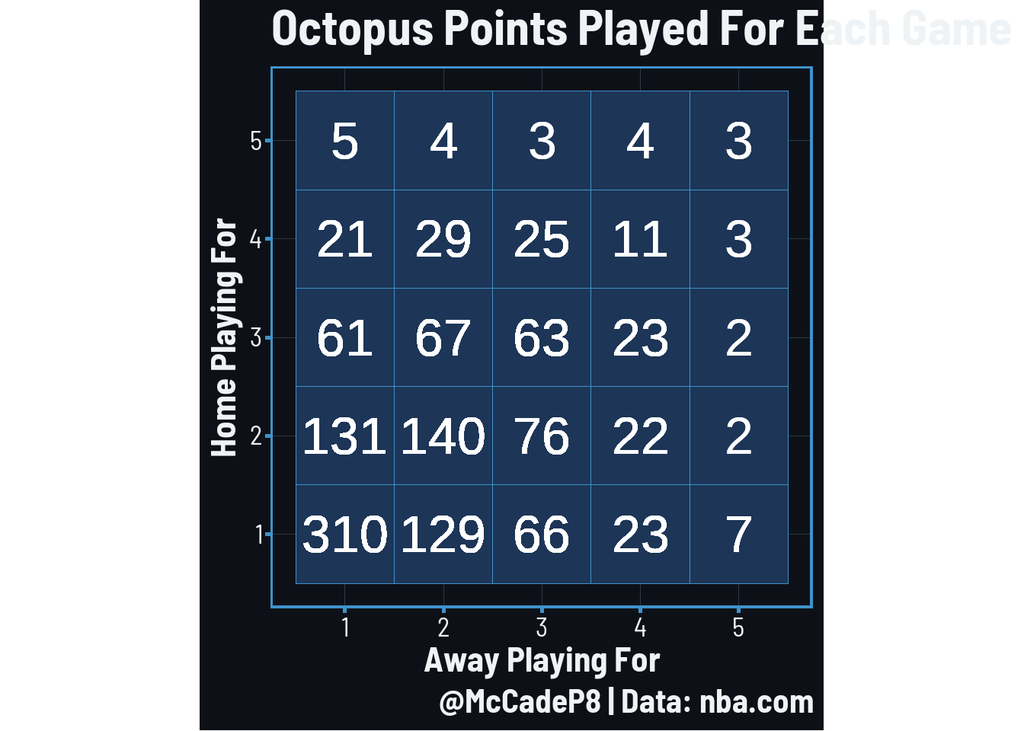

```r
TotalSchedule <- bind_rows(Schedules)
HomeSchedule <- TotalSchedule %>%
  filter(Game == "Home") %>%
  rename(HLeg = Leg,
         HRunWins = RunWins,
         HPoints = Points,
         HPointsPlaying = PointsPlaying,
         HGameLeg = GameLeg,
         HRunningPts = RunningPts) %>%
  select(game_id, HLeg, HRunWins, HPoints, HPointsPlaying, HGameLeg, HRunningPts)
TotalSchedule <- TotalSchedule %>%
  filter(Game == "Away") %>%
  rename(ALeg = Leg,
         ARunWins = RunWins,
         APoints = Points,
         APointsPlaying = PointsPlaying,
         AGameLeg = GameLeg,
         ARunningPts = RunningPts) %>%
  left_join(HomeSchedule, by = "game_id") %>%
  rename(Away = Team,
         AScore = TeamScore,
         HScore = OpponentScore,
         Home = Opponent,
         AwayWin = TeamWin) %>%
  select(-OpponentLogo,-Opponent2, -Game) %>%
  mutate(date = substr(date, 1, 10),
         date = as.Date(date)) %>%
  group_by(APointsPlaying, HPointsPlaying) %>%
  mutate(Total = n()) %>%
  ungroup() %>%
  mutate(PointsPlaying = APointsPlaying+HPointsPlaying)

ggplot(TotalSchedule) +
  geom_tile(aes(x = APointsPlaying, y = HPointsPlaying), fill = "#1D3557", color = "#3E92CC") +
  geom_text(aes(x = APointsPlaying, y = HPointsPlaying, label = Total), color = "white", size = 9) +
  coord_fixed() +
  theme_McCadeP8() +
  labs(x = "Away Playing For",
       y = "Home Playing For",
       title = "Octopus Points Played For Each Game",
       caption = "@McCadeP8 | Data: nba.com") +
  theme(panel.background = element_blank())
```

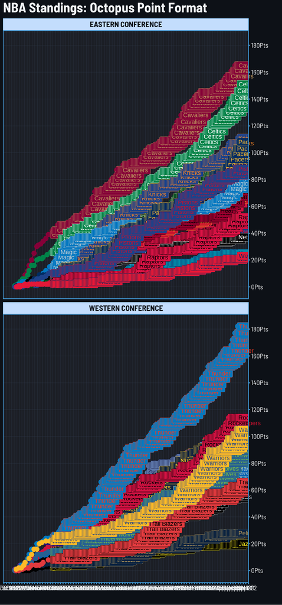

```r
TotalSchedule <- bind_rows(Schedules)
TotalSchedule <- TotalSchedule %>%
  left_join(Teams, by = c('Team' = 'home_name')) %>%
  mutate(date = substr(date, 1, 10),
         date = as.Date(date),
         Conf = ifelse(home_abbreviation %in% east, "Eastern Conference", "Western Conference"),
         home_color = paste0("#",home_color))
BaseTable <-
  expand.grid(Team = unique(all_schedule$home_name),
              Date = seq(as.Date("2024-10-22"), as.Date("2025-04-13"), by = "day"),
              Frame = seq(as.Date("2024-11-19"), as.Date("2025-04-13"), by = "day")) %>%
  mutate(Team = as.character(Team),
         DaysDiff = Frame-Date) %>%
  filter(DaysDiff >= 0 & DaysDiff <= 28) %>%
  select(-DaysDiff) %>%
  mutate(Frame = Frame-as.Date("2024-11-18"),
         Frame = as.numeric(Frame)) %>%
  left_join(TotalSchedule, by = c('Team', 'Date' = 'date')) %>%
  mutate(PlayedToday = ifelse(is.na(TeamScore == T), F, T)) %>%
  select(Team, Date, RunningPts, PlayedToday, Frame) %>%
  arrange(Team, Frame, Date)
StandingsByDay <- BaseTable %>%
  select(Team, Date, RunningPts) %>%
  arrange(Team, Date) %>%
  group_by(Team) %>%
  fill(RunningPts, .direction = "down") %>%
  ungroup() %>%
  mutate(RunningPts = ifelse(is.na(RunningPts) == T, 0, RunningPts)) %>%
  left_join(Teams, by = c('Team' = 'home_name')) %>%
  mutate(home_color = paste0("#",home_color),
         home_alternate_color = paste0("#",home_alternate_color),
         Conf = ifelse(home_abbreviation %in% east, "EASTERN CONFERENCE", "WESTERN CONFERENCE")) %>%
  distinct()
BaseTable <- BaseTable %>%
  select(-RunningPts) %>%
  left_join(StandingsByDay, by = c('Team', 'Date'))
LabelData <- BaseTable %>%
  group_by(Team, Frame) %>%
  mutate(Rk = n():1) %>%
  filter(Rk == 1) %>%
  select(-Rk)
Games <- BaseTable %>%
  filter(PlayedToday == T)

ggplot() +
    geom_line(data = BaseTable, aes(x = Date, y = RunningPts, group = Team, color = home_color), size = 1) +
    geom_point(data = Games, aes(x = Date+0.5, y = RunningPts, color = home_color), size = 4) +
    geom_label(data = LabelData, aes(x = Date, y = RunningPts, label = Team, fill = home_color, color = home_alternate_color), hjust = 0) +
    scale_color_identity() +
    scale_fill_identity() +
    scale_x_date(date_labels = "%b %e", date_breaks = "2 days") +
    scale_y_continuous(position = "right", breaks = seq(0,180, by = 20), labels = function(x) paste0(x, "Pts")) +
    theme_McCadeP8() +
    theme(axis.text = element_text(size = 12), strip.text = element_text(size = 14, face = "bold")) +
    labs(title = "NBA Standings: Octopus Point Format",
         x = "",
         y = "") +
    facet_wrap(~Conf, ncol = 1)
```

```r
    #transition_states(Frame) +
    #ease_aes('linear') +
    #view_follow(fixed_x = FALSE)

#animate(p, width = 1600, height = 1200, fps = 4, duration = 36, renderer = gifski_renderer("nba_standings_animation.gif"))
```

[figure not shown]

```r
TotalSchedule <- bind_rows(Schedules)
HomeSchedule <- TotalSchedule %>%
  filter(Game == "Home") %>%
  rename(HLeg = Leg,
         HRunWins = RunWins,
         HPoints = Points,
         HPointsPlaying = PointsPlaying,
         HGameLeg = GameLeg,
         HRunningPts = RunningPts) %>%
  select(game_id, HLeg, HRunWins, HPoints, HPointsPlaying, HGameLeg, HRunningPts)
TotalSchedule <- TotalSchedule %>%
  filter(Game == "Away") %>%
  rename(
    ALeg = Leg,
    ARunWins = RunWins,
    APoints = Points,
    APointsPlaying = PointsPlaying,
    AGameLeg = GameLeg,
    ARunningPts = RunningPts) %>%
  left_join(HomeSchedule, by = "game_id") %>%
  rename(Away = Team,
         AScore = TeamScore,
         HScore = OpponentScore,
         Home = Opponent,
         AwayWin = TeamWin) %>%
  select(-OpponentLogo,-Opponent2, -Game) %>%
  mutate(date = substr(date, 1, 10),
         date = as.Date(date)) %>%
  group_by(APointsPlaying, HPointsPlaying) %>%
  mutate(Total = n()) %>%
  ungroup() %>%
  mutate(PointsPlaying = APointsPlaying + HPointsPlaying)
DailyAvg <- TotalSchedule %>%
  group_by(date) %>%
  summarise(DailyPts = mean(PointsPlaying), .groups = 'drop') %>%
  arrange(date) %>%
  mutate(RollAvg = rollmean(DailyPts, k = 4, fill = NA, align = "right")) %>%
  select(date, RollAvg)
TotalSchedule <- TotalSchedule %>%
  left_join(DailyAvg, by = "date") %>%
  select(date, PointsPlaying, RollAvg) %>%
  mutate(Day = as.numeric(date)-20017)
TotalSchedule$PointsPlaying <- TotalSchedule$PointsPlaying +
  runif(nrow(TotalSchedule), min = -0.33, max = 0.33)
Total <- map(1:174, ~ mutate(TotalSchedule, Frame = .x))
TotalSchedule <- bind_rows(Total)
TotalSchedule <- TotalSchedule %>%
  mutate(Test = Day-Frame,
         RollAvg = ifelse(Test > 0, NA, RollAvg)) %>%
  select(date, PointsPlaying, RollAvg, Frame, Day, Test) %>%
  mutate(Frame = Frame-3) %>%
  filter(Frame >= 1) %>%
  arrange(Frame, date)

ggplot(TotalSchedule) +
  geom_point(aes(x = date, y = PointsPlaying), color = "#CCCCCC", alpha = 0.6) +
  scale_y_continuous(breaks = 2:12, labels = 2:12, limits = c(1,12)) +
  labs(title = "Eight Arms of Urgency: Unveiling the OCTOPUS Point System for NBA Games",
       y = "Combined Incentive Score",
       x = NULL,
       caption = "@McCadeP8 | Data: nba.com") +
  theme_McCadeP8() +
  theme(axis.text.x = element_text(angle = 0, hjust = 0.5)) +
  geom_line(aes(x = date, y = RollAvg), color = "#CC0000", size = 1.2)
```

```r
  #transition_states(Frame,
                   #transition_length = 1,
                   #state_length = 1)

#animate(p, duration = 8, fps = 10, width = 1000, height = 616, start_pause = 5, end_pause = 10, renderer = gifski_renderer("game_value.gif"))
```

```r
team_dfs <- list()

for (team_name in names(Schedules)) {

  df <- Schedules[[team_name]]

  leg_summary <- df %>%
    group_by(Team, Leg) %>%
    summarise(
      TeamWins = list(TeamWin),
      TotalWins = sum(TeamWin),
      TotalPoints = sum(Points),
      .groups = "drop"
    )

  leg_summary_wide <- leg_summary %>%
    mutate(Leg = paste0("Leg", Leg)) %>%
    pivot_wider(
      names_from = Leg,
      values_from = c(TeamWins, TotalWins, TotalPoints),
      names_glue = "{.value}_{Leg}"
    )

  leg_cols_ordered <- c("Team", unlist(map(1:8, function(i) {
    paste0(c("TeamWins_Leg", "TotalWins_Leg", "TotalPoints_Leg"), i)
  })))

  team_df <- leg_summary_wide %>%
    select(all_of(leg_cols_ordered)) %>%
    mutate(
      TotalWins = TotalWins_Leg1 + TotalWins_Leg2 + TotalWins_Leg3 + TotalWins_Leg4 +
                  TotalWins_Leg5 + TotalWins_Leg6 + TotalWins_Leg7 + TotalWins_Leg8,
      TotalPoints = TotalPoints_Leg1 + TotalPoints_Leg2 + TotalPoints_Leg3 + TotalPoints_Leg4 +
                    TotalPoints_Leg5 + TotalPoints_Leg6 + TotalPoints_Leg7 + TotalPoints_Leg8,
      TotalWins_Leg1 = paste0(TotalWins_Leg1, "-", 10 - TotalWins_Leg1),
      TotalPoints_Leg1 = paste0(TotalPoints_Leg1, "pts"),
      TotalWins_Leg2 = paste0(TotalWins_Leg2, "-", 10 - TotalWins_Leg2),
      TotalPoints_Leg2 = paste0(TotalPoints_Leg2, "pts"),
      TotalWins_Leg3 = paste0(TotalWins_Leg3, "-", 10 - TotalWins_Leg3),
      TotalPoints_Leg3 = paste0(TotalPoints_Leg3, "pts"),
      TotalWins_Leg4 = paste0(TotalWins_Leg4, "-", 10 - TotalWins_Leg4),
      TotalPoints_Leg4 = paste0(TotalPoints_Leg4, "pts"),
      TotalWins_Leg5 = paste0(TotalWins_Leg5, "-", 10 - TotalWins_Leg5),
      TotalPoints_Leg5 = paste0(TotalPoints_Leg5, "pts"),
      TotalWins_Leg6 = paste0(TotalWins_Leg6, "-", 10 - TotalWins_Leg6),
      TotalPoints_Leg6 = paste0(TotalPoints_Leg6, "pts"),
      TotalWins_Leg7 = paste0(TotalWins_Leg7, "-", 10 - TotalWins_Leg7),
      TotalPoints_Leg7 = paste0(TotalPoints_Leg7, "pts"),
      TotalWins_Leg8 = paste0(TotalWins_Leg8, "-", 12 - TotalWins_Leg8),
      TotalPoints_Leg8 = paste0(TotalPoints_Leg8, "pts"),
      TotalWins = paste0(TotalWins, "-", 82 - TotalWins))
  team_dfs[[team_name]] <- team_df}

FinalDF <- bind_rows(team_dfs)

FinalDF <- FinalDF %>%
  arrange(-TotalPoints) %>%
  mutate(TotalPoints = paste0(TotalPoints,"pts")) %>%
  left_join(Teams, by = c('Team' = 'home_name')) %>%
  select(-Team, -home_alternate_color, -home_display_name, -home_color, -home_abbreviation) %>%
  select(27, 1:26)

gt(FinalDF) %>%
  gt_theme_espn() %>%
  text_transform(locations = cells_body(columns = home_logo),
    fn = function(x) {web_image(url = FinalDF$home_logo, height = as.numeric(40))}) %>%
  gt_plt_winloss(TeamWins_Leg1, type = "pill", max_wins = 10, palette = c("#8CD47E", "#FF6961", "gray")) %>%
  gt_merge_stack(col1 = TotalWins_Leg1, col2 = TotalPoints_Leg1) %>%
  gt_plt_winloss(TeamWins_Leg2, type = "pill", max_wins = 10, palette = c("#8CD47E", "#FF6961", "gray")) %>%
  gt_merge_stack(col1 = TotalWins_Leg2, col2 = TotalPoints_Leg2) %>%
  gt_plt_winloss(TeamWins_Leg3, type = "pill", max_wins = 10, palette = c("#8CD47E", "#FF6961", "gray")) %>%
  gt_merge_stack(col1 = TotalWins_Leg3, col2 = TotalPoints_Leg3) %>%
  gt_plt_winloss(TeamWins_Leg4, type = "pill", max_wins = 10, palette = c("#8CD47E", "#FF6961", "gray")) %>%
  gt_merge_stack(col1 = TotalWins_Leg4, col2 = TotalPoints_Leg4) %>%
  gt_plt_winloss(TeamWins_Leg5, type = "pill", max_wins = 10, palette = c("#8CD47E", "#FF6961", "gray")) %>%
  gt_merge_stack(col1 = TotalWins_Leg5, col2 = TotalPoints_Leg5) %>%
  gt_plt_winloss(TeamWins_Leg6, type = "pill", max_wins = 10, palette = c("#8CD47E", "#FF6961", "gray")) %>%
  gt_merge_stack(col1 = TotalWins_Leg6, col2 = TotalPoints_Leg6) %>%
  gt_plt_winloss(TeamWins_Leg7, type = "pill", max_wins = 10, palette = c("#8CD47E", "#FF6961", "gray")) %>%
  gt_merge_stack(col1 = TotalWins_Leg7, col2 = TotalPoints_Leg7) %>%
  gt_plt_winloss(TeamWins_Leg8, type = "pill", max_wins = 12, palette = c("#8CD47E", "#FF6961", "gray")) %>%
  gt_merge_stack(col1 = TotalWins_Leg8, col2 = TotalPoints_Leg8) %>%
  cols_label(TeamWins_Leg1 = "Game Log",
             TotalWins_Leg1 = "Record",
             TeamWins_Leg2 = "Game Log",
             TotalWins_Leg2 = "Record",
             TeamWins_Leg3 = "Game Log",
             TotalWins_Leg3 = "Record",
             TeamWins_Leg4 = "Game Log",
             TotalWins_Leg4 = "Record",
             TeamWins_Leg5 = "Game Log",
             TotalWins_Leg5 = "Record",
             TeamWins_Leg6 = "Game Log",
             TotalWins_Leg6 = "Record",
             TeamWins_Leg7 = "Game Log",
             TotalWins_Leg7 = "Record",
             TeamWins_Leg8 = "Game Log",
             TotalWins_Leg8 = "Record",
             TotalWins = "Record",
             TotalPoints = "Points",
             home_logo = "") %>%
  tab_spanner(label = "Leg 1", columns = c(TeamWins_Leg1, TotalWins_Leg1)) %>%
  tab_spanner(label = "Leg 2", columns = c(TeamWins_Leg2, TotalWins_Leg2)) %>%
  tab_spanner(label = "Leg 3", columns = c(TeamWins_Leg3, TotalWins_Leg3)) %>%
  tab_spanner(label = "Leg 4", columns = c(TeamWins_Leg4, TotalWins_Leg4)) %>%
  tab_spanner(label = "Leg 5", columns = c(TeamWins_Leg5, TotalWins_Leg5)) %>%
  tab_spanner(label = "Leg 6", columns = c(TeamWins_Leg6, TotalWins_Leg6)) %>%
  tab_spanner(label = "Leg 7", columns = c(TeamWins_Leg7, TotalWins_Leg7)) %>%
  tab_spanner(label = "Leg 8", columns = c(TeamWins_Leg8, TotalWins_Leg8)) %>%
  tab_spanner(label = "Total", columns = c(TotalWins, TotalPoints)) %>%
  cols_align(columns = everything(), align = c('center')) %>%
  tab_source_note(source_note = "@McCadeP8 | Data: nba.com") %>%
  tab_header(title = md("**Big Picture View of Octopus Format in 2024-25 Season**")) %>%
  opt_align_table_header(align = c('center'))
```

**Big Picture View of Octopus Format in 2024-25 Season**

Leg 1

Leg 2

Leg 3

Leg 4

Leg 5

Leg 6

Leg 7

Leg 8

Total

Game Log

Record

Game Log

Record

Game Log

Record

Game Log

Record

Game Log

Record

Game Log

Record

Game Log

Record

Game Log

Record

Record

Points

8-2

20pts

7-3

16pts

10-0

30pts

9-1

25pts

7-3

16pts

8-2

20pts

9-1

25pts

10-2

30pts

68-14

182pts

10-0

30pts

7-3

16pts

9-1

25pts

8-2

20pts

6-4

12pts

10-0

30pts

6-4

12pts

8-4

20pts

64-18

165pts

8-2

20pts

8-2

20pts

6-4

12pts

6-4

12pts

7-3

16pts

7-3

16pts

9-1

25pts

10-2

30pts

61-21

151pts

6-4

12pts

8-2

20pts

7-3

16pts

6-4

12pts

5-5

9pts

5-5

9pts

8-2

20pts

7-5

16pts

52-30

114pts

5-5

9pts

7-3

16pts

8-2

20pts

6-4

12pts

7-3

16pts

7-3

16pts

4-6

6pts

7-5

16pts

51-31

111pts

6-4

12pts

6-4

12pts

5-5

9pts

6-4

12pts

5-5

9pts

4-6

6pts

8-2

20pts

10-2

30pts

50-32

110pts

6-4

12pts

6-4

12pts

5-5

9pts

5-5

9pts

9-1

25pts

8-2

20pts

4-6

6pts

7-5

16pts

50-32

109pts

5-5

9pts

4-6

6pts

6-4

12pts

7-3

16pts

7-3

16pts

6-4

12pts

6-4

12pts

9-3

25pts

50-32

108pts

[figure not shown]

2-8

2pts

9-1

25pts

5-5

9pts

7-3

16pts

4-6

6pts

8-2

20pts

5-5

9pts

8-4

20pts

48-34

107pts

7-3

16pts

4-6

6pts

6-4

12pts

7-3

16pts

7-3

16pts

8-2

20pts

5-5

9pts

6-6

12pts

50-32

107pts

[figure not shown]

6-4

12pts

4-6

6pts

6-4

12pts

5-5

9pts

6-4

12pts

5-5

9pts

8-2

20pts

9-3

25pts

49-33

105pts

8-2

20pts

4-6

6pts

3-7

4pts

5-5

9pts

5-5

9pts

7-3

16pts

9-1

25pts

7-5

16pts

48-34

105pts

[figure not shown]

6-4

12pts

7-3

16pts

7-3

16pts

5-5

9pts

9-1

25pts

4-6

6pts

5-5

9pts

5-7

9pts

48-34

102pts

4-6

6pts

4-6

6pts

5-5

9pts

8-2

20pts

4-6

6pts

8-2

20pts

6-4

12pts

5-7

9pts

44-38

88pts

4-6

6pts

9-1

25pts

5-5

9pts

4-6

6pts

2-8

2pts

5-5

9pts

3-7

4pts

9-3

25pts

41-41

86pts

[figure not shown]

6-4

12pts

3-7

4pts

4-6

6pts

7-3

16pts

5-5

9pts

7-3

16pts

3-7

4pts

5-7

9pts

40-42

76pts

[figure not shown]

5-5

9pts

7-3

16pts

7-3

16pts

3-7

4pts

4-6

6pts

6-4

12pts

1-9

1pts

6-6

12pts

39-43

76pts

[figure not shown]

4-6

6pts

5-5

9pts

6-4

12pts

6-4

12pts

2-8

2pts

4-6

6pts

7-3

16pts

6-6

12pts

40-42

75pts

4-6

6pts

4-6

6pts

5-5

9pts

5-5

9pts

3-7

4pts

3-7

4pts

6-4

12pts

9-3

25pts

39-43

75pts

4-6

6pts

6-4

12pts

6-4

12pts

4-6

6pts

5-5

9pts

4-6

6pts

0-10

0pts

8-4

20pts

37-45

71pts

[figure not shown]

3-7

4pts

5-5

9pts

2-8

2pts

3-7

4pts

8-2

20pts

6-4

12pts

4-6

6pts

5-7

9pts

36-46

66pts

[figure not shown]

8-2